# Pupil Trajectories in Response to Light Stimulus – FDA Analysis

SG

2023-02-02

# 1 Background

Pupil size reflex to a light test is a potential test to determine if a person is under the influence of THC and can be used as a field sobriety measure. For this analysis we’ll be using methods from a statistical area called functional data analysis (FDA) which allows us to model the entire trajectory of the pupil reflex for each subject and discern differences between groups in the trajectories and in specific areas of the trajectory. This is in contrast to more traditional techniques which require extracting single summary measures such as the point of minimal constriction.

## 1.1 What is Functional Data Analysis?

Functional Data analysis (FDA) is a field of statistics that models curves or trajectories of information without extracting pre-defined specific features. It allows us to examine the sources of variation of these curves (fPCA), how differences in the patterns of the curves relate to an outcome, and how the patterns of the curves differ based on individual characteristics.

## 1.2 Data summary

Full pupil trajectories of pupil size during light reflex test. Pupil size was extracted at the image level based on image analysis techniques (Ben Steinhart’s video segmentation pipeline). Each test was performed simultaneously on right and left eye before and after THC use (smoking).

- Outcome: percent change from baseline
- Start at frame 0
- End of test is not strictly defined (with FoSR we shouldn’t need to define the end of the test)
- **Analysis to focus on data from post assessment of right eye**

## 1.3 Summary of Findings – POST data

- Prediction Analysis (ROC) with full pupil response trajectories, or scalar features
  - Objective: Define a model that discriminates between smokers and non-smokers
    - AUC values ranged from 0.68-0.71
    - The models were not statistically significantly different
- Function on Scalar Regression (FoSR)
  - Objective: Model differences in pupil response trajectories by user category
    - Significant differences between Occasional and non-Users in the minimal constriction interval
    - Significant differences between Daily and non-Users in the minimal constriction interval
    - No significant differences between Occasional and Daily users.
  - Objective: Model variations in pupil response trajectories by smokers vs non-smokers
    - Significant differences between Smokers and non-Smokers in the minimal constriction interval
  - New models including Post Consumption time to test (PCTT) for smokers, show similar trajectories but with longer PCTT associated with a stronger minimal constriction
- Functional principal components analysis (fPCA)
  - point of minimal constriction and rebound shapes drive the first and second PCs

## 1.4 Questions for collaborators

- Paper Development
  - Target Journal
  - Focus: In post assessment of pupil response trajectories, there are significant differences between occasional and non-user and smaller significant differences in daily and non-users, but no significant differences between occasional and daily users. These results indicate a reduced effect of tolerance on pupil response trajectory.
- VAS (feeling high)
  - Discussed at previous meeting as a potential effect in occasional users.
  - Odd associations in pre- and post- data for occasional users show “feeling higher” correlates with a stronger minimal constriction. Need clarification

# 2 Exploratory Analysis

*This is a recap from the previous meeting*

Plot of PRE/POST for Right Eye

We’d examined the plot for the left and right eye and found them to be similar, so for this analysis we’ll used data from the right eye.

There was some attenuation of the initial light reflex response between pre and post measures in most participants, but there is a lot of variability in the recovery trajectories (both duration and shape). We’ll be exploring if these differences are significantly related to the participant’s THC use category and if there might be differences by smoker vs non-smoker.

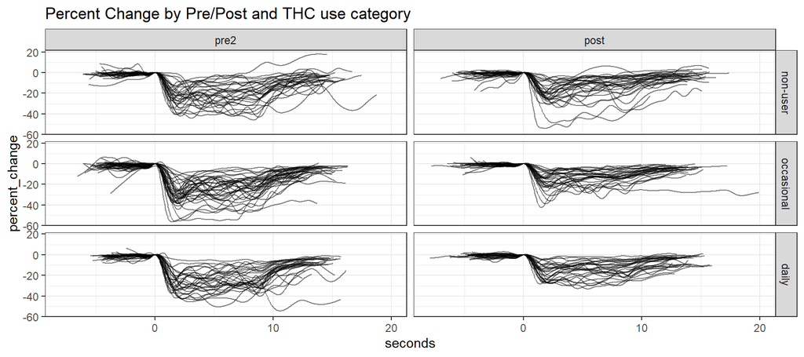

Right Eye: Pre/Post Trajectories

Most participant’s are missing data after frame 400.

## 2.1 Analytic Sample

There were 84 participants with both pre and post data which constituted the analytic sample. In this sample, there are 29 non-users, 30 occasional, and 25 daily users.

# 3 Analysis

## 3.1 Prediction Analysis: Smoker vs non-Smoker

3 logistic regression models using one of the following types of variables:

- PC scores from the fPCA analysis
- scalar features from Ben’s pipeline (single variables)
- predicted values from a scalar-on-function (SoFR) regression model. A SoFR model, uses the whole pupil change trajectory to model a scalar outcome (e.g. smoker or non-smoker).

Using logistic regression models, we attempted to classify smokers and non-smokers. The SoFR model had the best prediction using an area under the curve (AUC) metric; however the AUC from these models were not statistically significantly different.

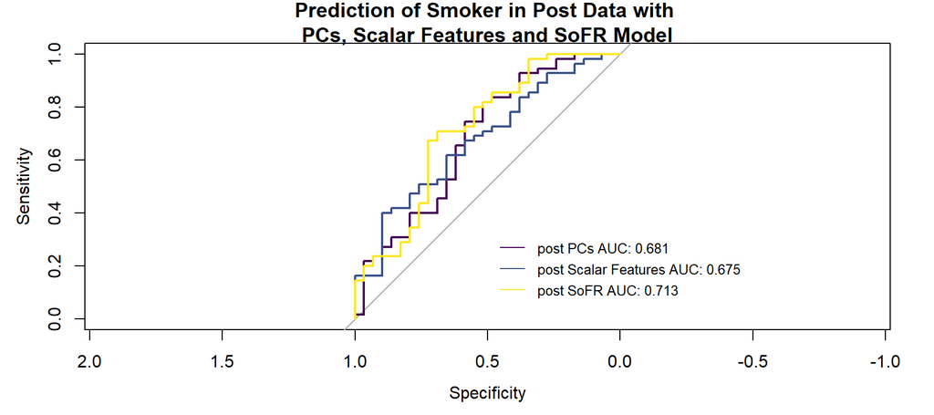

ROC Curves

### 3.1.1 Scalar on Function Regression (SoFR)

Scalar on Function Regression (SoFR) is a regression method that regresses a scalar value (eg. smoking status) on the full trajectory of the pupil light reflex (e.g. function). This analysis allows us to examine differences in smoking status by pupil light reflex trajectories. However, missingness in the trajectories has a large effect on the associations produced by the model, so fPCA was used to impute missing values before performing this analysis.

## 3.2 Function on Scalar Regression (FoSR)

Function on Scalar Regression (FoSR) is a regression method that regresses the full trajectory of the pupil light reflex (e.g. function) on set of scalar predictor, in this case THC user category and accounts for the between subject variability with a random effect term. This analysis allows us to examine differences in trajectories or parts of the trajectory by THC user group.

- In this analysis, we found significant differences between occasional and non-users and smaller significant differences between daily and non-users in the time period related to minimal constriction. There were no significant differences between occasional and daily users.

### 3.2.1 Differences by User Category

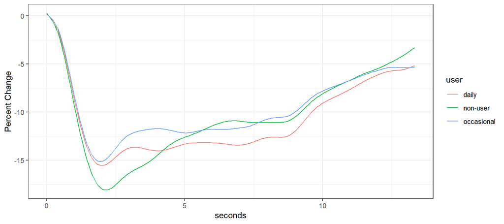

Average Trajectories by User Category

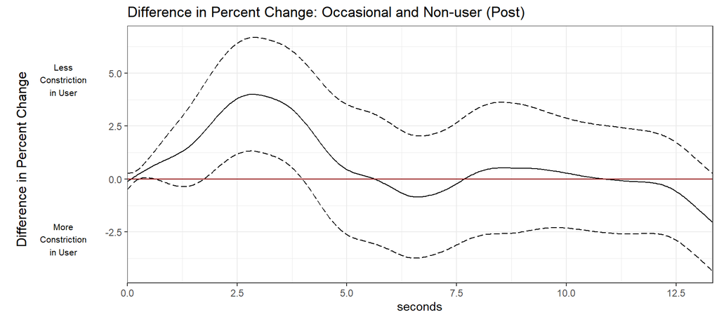

Differences in Occasional and Non-Users

There is statistically significant difference in trajectories between occasional and non-users from approximately 1.5 to 3.75 seconds, which corresponds to the minimal constriction value.

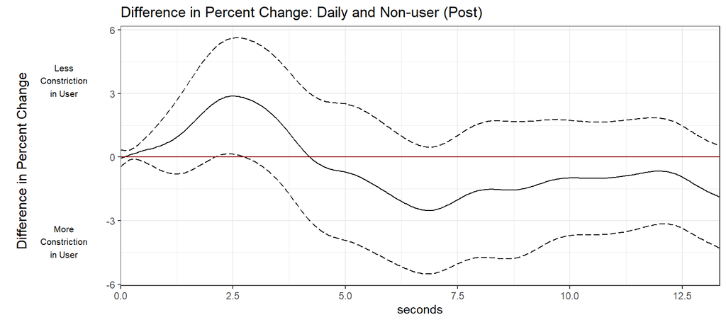

Differences in Daily and Non-Users

There is statistically significant difference in trajectories between daily and non-users around 2.4 seconds, which corresponds to the minimal constriction value.

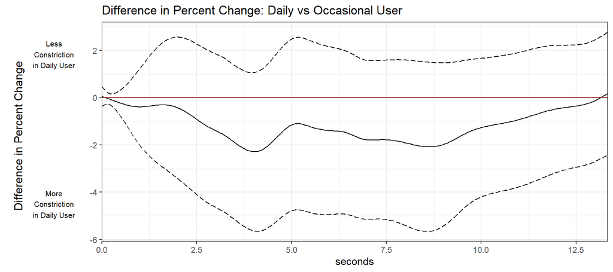

Differences in Occasional and Daily Users

There is not statistically significant difference in trajectories between occasional and daily users.

### 3.2.2 Differences by Smoking Status

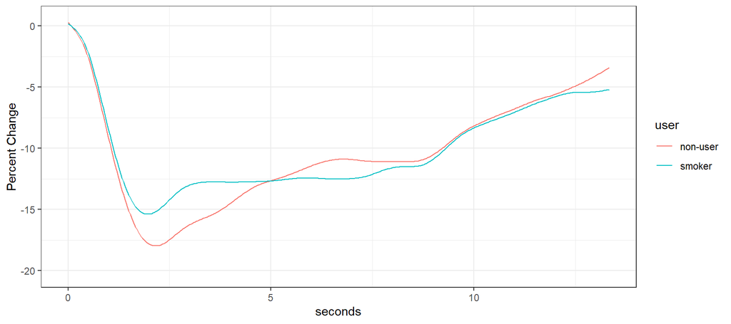

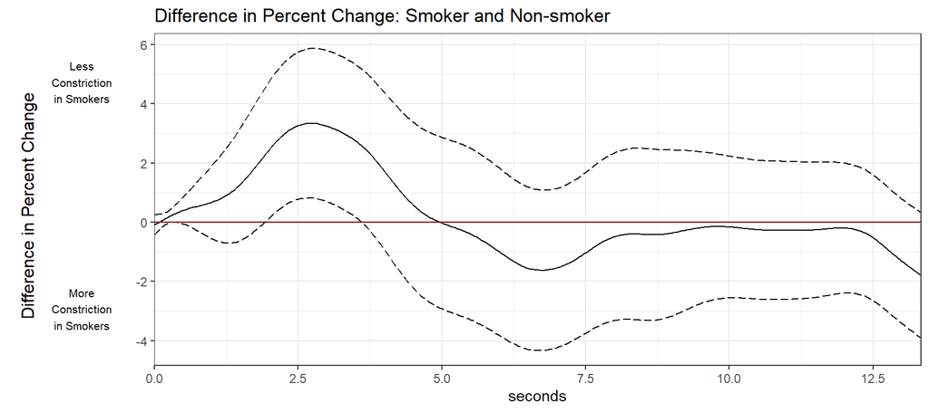

There is statistically significant difference in trajectories between smokers and non-smokers from approximately 2 to 3 seconds, which corresponds to the minimal constriction value.

## 3.3 Post Consumption Time to Test (PCTT)

To examine the effect of post consumption time to test (PCTT) on the pupil trajectories, we fit a FoSR model in smokers and non-smokers with an interaction term for PCTT in smokers.

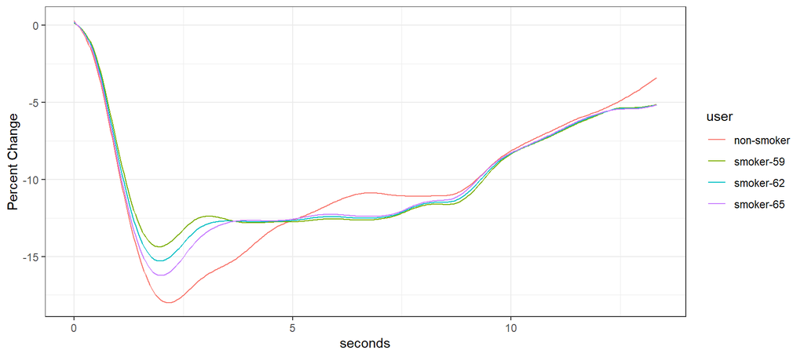

Average Trajectory of non-Smokers and Smokers with varying PCTT

As seen above, this model showed a stronger minimal constriction in non-smokers and small differences between smokers based on PCTT, with longer PCTT corresponding to average trajectories with stronger minimal constriction; however these effects do not appear to be statistically significant.

We need to explore allowing the shape of the trajectories to vary by PCTT and time using a joint functional model for these two variables.

## 3.4 functional Principal Components Analysis (fPCA)

Similar to PCA, fPCA is a method to quantify the sources of variation in the data. With fPCA, we’re finding functions or “shapes” that describe variation.

### 3.4.1 fPCA post data

Truncating to frame 400

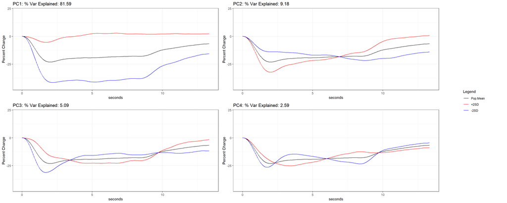

fPCA POST data

## 3.5 Paper Discussion

1. Focus: In post assessment of pupil response trajectories, there are significant differences between occasional and non-user and smaller significant differences in daily and non-users, but no significant differences between occasional and daily users. These results indicate a reduced effect of tolerance on pupil response trajectory.
2. Target Journal?

## 3.6 VAS – Feeling High

The VAS score was used to assess “feeling high” in smokers after THC consumption. In this analysis we are interested in examining differences in pupil trajectories with different values of “feeling high”. Initially the VAS score was dichotomized to create a group of “high” vs “not high” participants, and a FoSR model was used to evaluate trajectories in these groups.

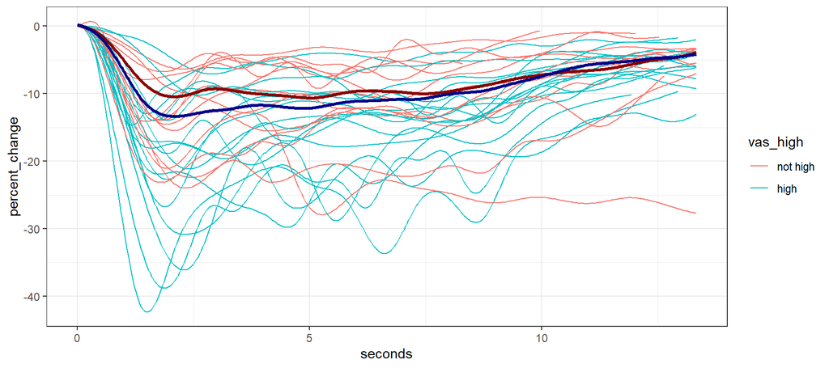

Unexpectedly, as seen in the plot, users that felt more high had a stronger minimal constriction, so we decided to examine the scalar feature of minimal constriction along with user category in the for both pre- and post- time points and difference between them, as shown in the following series of plots.

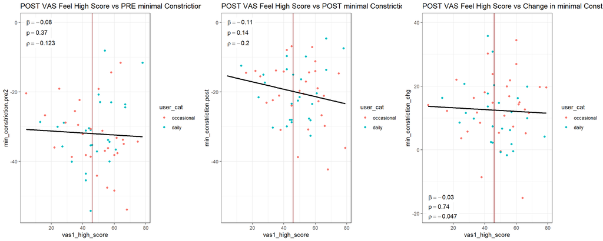

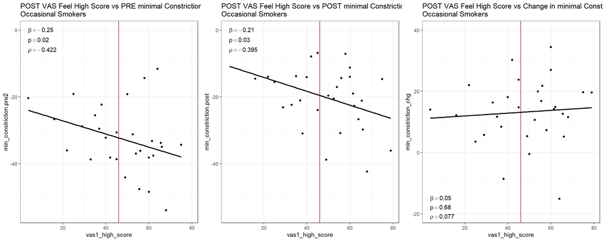

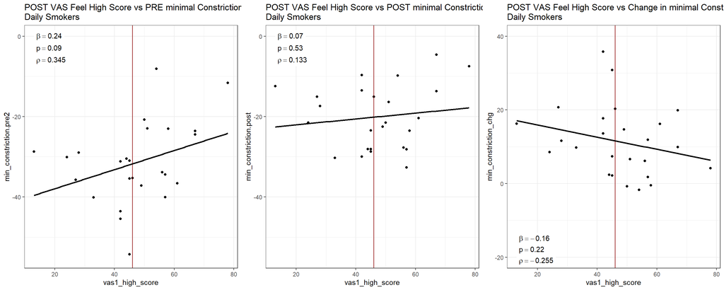

In these plots we see a odd negative correlation in occasional users, with a higher VAS score associated with a stronger minimal constriction.

We’d appreciate any input on whether there is a biological mechanism in action to account for this correlation or if it might be due to random chance (our current understanding).